# Lab style plots

## Lab Style

last updated “2022-07-26”

This repo contains the functions of the `labPlots` package, which, once installed locally, provides useful functions for creating graphics made in ggplot2 in the style the Collins Lab uses. The package and this doc borrows (steals) heavily from the bbplots package and makes use of the ggPrism code for adding P values to plots (as an aside, if you want your plots to look like they were made in GraphPad prism, the ggprism package is for you!).

## Load all the libraries you need

A few steps in this cookbook - and to create charts in R in general - require specific packages to be installed and loaded. So that you do not have to install and load them one by one, you can use the p_load function in the Pacman package

```r
# This line of code installs the pacman package if you do not have it
# installed - if you do, it simply loads the package

if(!require(pacman))install.packages("pacman")
```

```r
pacman::p_load(
  'dplyr',
  'tidyr',
  'gapminder',
  'ggplot2',
  'ggalt',
  'ragg',
  'R.utils',
  'pander',
  'ggpubr',
  'scales',
  'rstatix',
  'DT'
)
```

## Installing labPlots package

`labPlots` is not on CRAN, so you will have to install it directly from Github using `devtools`.

If you do not have the `devtools` package installed, you will also have to run the first line in the code below. **Hint - remove the ‘#’ from the first line if you need to install devtools.**

```r
# install.packages("devtools")
devtools::install_github("JT-Collins/labPlots")
```

## Seting up font and colours

You must ensure the **Gotham Book** font is installed on your computer. This font is used in the lab PowerPoint and Poster templates, as well as the plots for consistency. If not already installed, the **Gotham Book** fonts can be found on BOX `~\Box\Lab Docs\R projects\aesthetics\fonts`. For Windows machines, the fonts can be installed by simply double-clicking. To initiate the font in R, run `lab_fonts()` following the loading of the `labPlots` package

Depending on the plot, you may want/need to change the colors used. However, as a default, we will use the UofL color palette.

## How does the labPlot package work?

The package has three functions,`lab_fonts()` as i’ve mentioned, `lab_style()`, and `add_pvalue()`.

`lab_fonts()`: Sets fonts to Gotham Book. Run it once at the start of a session.

`lab_style()`: Has no arguments and is added to the ggplot ‘chain’ after you have created a plot. It generally makes text size, font and colour, axis lines, axis text, margins, and many other standard chart components into Lab style.

Note that colours for lines in the case of a line chart or bars for a bar chart, are based on the UofL colour scheme but can be set to other colours where needed.

`add_pvalue()` can add the p values to a plot. These need to be calculated first using any suitable method; see [Here](https://csdaw.github.io/ggprism/articles/pvalues.html) for details. If you want to use an R package that will output your P-value in the correct format, then `rstatix` is what you want. See [Here](https://github.com/kassambara/rstatix) for in-depth info. I will provide examples later on.

The code below shows how the `lab_style()` should be used within the standard chart-production workflow. This is an example of a straightforward line chart using data from the gapminder package.

## Default Figure

Before we load up the fonts and make changes, let’s look at a default line graph

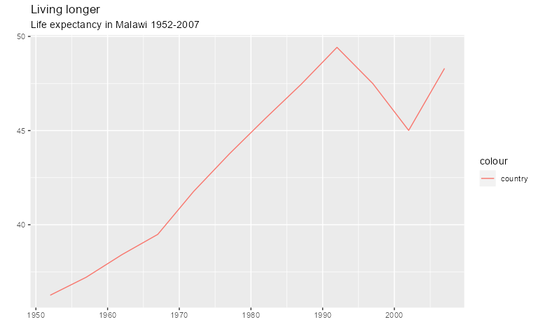

```r
#Data for chart from gapminder package
line_df <- gapminder |>
  filter(country == "Malawi")

#Make plot
line_old <-
  ggplot(line_df, aes(x = year, y = lifeExp, colour = 'country')) +
  geom_line() +
  labs(
    title = "Living longer",
    subtitle = "Life expectancy in Malawi 1952-2007",
    x = "",
    y = ""
  ) +
  NULL
```

## Load our package and set up lab fonts

```r
pacman::p_load('labPlots')
```

```r
lab_fonts()
```

Make a new plot with the `lab_style()` along with a few changes for improved clarity.

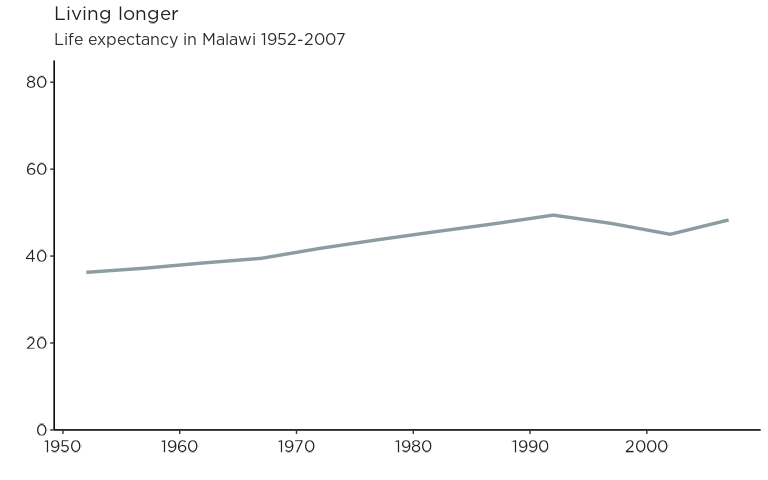

```r
#Make plot
line_new <-
  ggplot(line_df, aes(x = year, y = lifeExp, colour = country)) +
  geom_line(size = 1.2) +
  lab_style() +
  theme(legend.position = "none") + # removes legend - default is legend on the right
  scale_y_continuous(limits = c(0, 85), expand = c(0, 0)) + # limits sets y axis limits and expand removes white space (compare to previos plot). Feel free to delete this to see the default behaviour!
  labs(
    title = "Living longer",
    subtitle = "Life expectancy in Malawi 1952-2007",
    x = "",
    y = ""
  ) +
  NULL
```

It is possible to alter every aspect of a ggplot. Often you may have to change a couple of things, it’s important to do this after the call to the `lab_style()` function. If you do it before, the `lab_style()` will override it.

For example, this will add some gridlines by adding extra theme arguments to what is included in the lab_style() function. There are many similar examples throughout the cookbook.

```r
theme(panel.grid.major.y = element_line(color="#cbcbcb"))
```

## Save out your finished chart

After adding the lab_style() to your chart, one more step to get your plot ready for publication: ggsave(). This will save it to your specified location. The function has several arguments:

Here are the function arguments: `ggsave(plot_name, save_filepath, device = ragg::agg_png, res = 300, scaling = 1, width = x, height = x, units = "in")`

`plot_name`: the variable name that you have called your plot; for example, for the chart example above plot_name would be “line”. You can also leave this blank and ggsave will save the last plot.

`save_filepath`: the precise filepath that you want your graphic to save to, including the `.png` extension at the end. This does depend on your working directory and if you are in a specific R project. An example file path would be: `Desktop/R_projects/charts/line_chart.png`

`width, height, units`: Plot size in units (“in”, “cm”, “mm”, or “px”). If not supplied, uses the size of current graphics device.

`device`: `agg_png` provides improved saving and scaling for png files.

`res`: the resolution of the figure.

more information can be found by typing `?ggsave()` into the console.

Once you have created your plot and are relatively happy with it, you can use the `ggsave()` function to make the final adjustments and save your chart so that you can look at it outside RStudio.

It is a good idea to do this early on. The position of the text and other elements do not render accurately in the RStudio Plots panel because this depends on the size and aspect ratio of your plot. Saving and opening up the files give you an accurate representation of how the graphic looks.

## Make a line chart

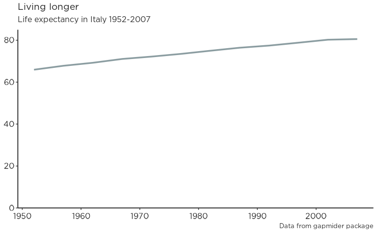

```r
#Prepare data
line_df <- gapminder |>
  filter(country == "Italy")

#Make plot
line <-
  ggplot(line_df, aes(x = year, y = lifeExp, colour = country)) +
  geom_line(size = 1.2) +
  lab_style() +
  theme(legend.position = "none") + # removes legend - default is legend on the right
  scale_y_continuous(limits = c(0, 85), expand = c(0, 0)) +
  labs(
    title = "Living longer",
    subtitle = "Life expectancy in Italy 1952-2007",
    caption = "Data from gapmider package",
    x = NULL,
    y = NULL
  ) +

  NULL
```

## Make a multiple line chart

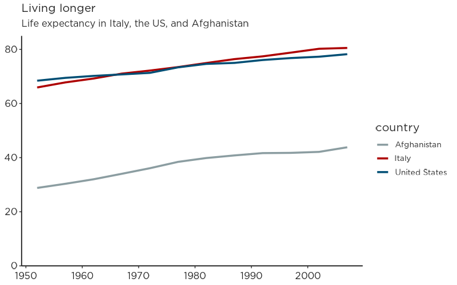

```r
#Prepare data
multiple_line_df <-
  gapminder |>
  filter(country == "Italy" |
           country == "United States" | country == "Afghanistan")

#Make plot
multiple_line <-
  ggplot(multiple_line_df, aes(x = year, y = lifeExp, colour = country)) +
  geom_line(size = 1.2) +
  lab_style() +
  scale_y_continuous(limits = c(0, 85), expand = c(0, 0)) +
  labs(
    title = "Living longer",
    subtitle = "Life expectancy in Italy, the US, and Afghanistan",
    x = NULL,
    y = NULL
  ) +
  NULL
```

If we wanted to move the legend to the bottom of the figure, we could simply do the following:

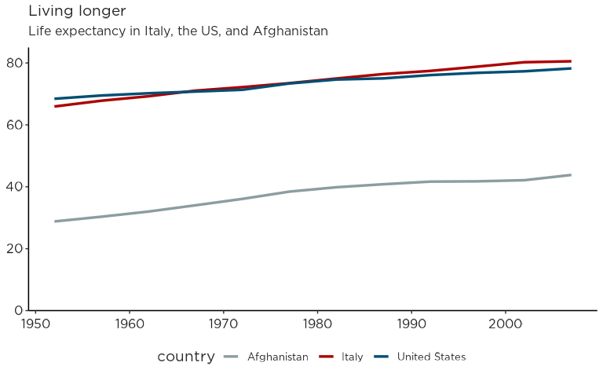

```r
multiple_line + theme(legend.position = "bottom")
```

## Make a bar chart

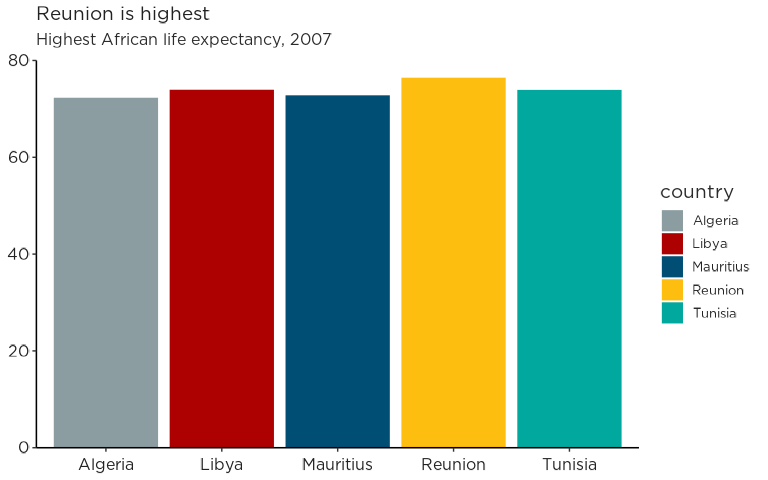

```r
#Prepare data
bar_df <- gapminder |>
  filter(year == 2007 & continent == "Africa") |>
  arrange(desc(lifeExp)) |> # This orders the data - try removing it and running
  head(5) # Selects the top 5

#Make plot
bars <-
  ggplot(bar_df, aes(x = country, y = lifeExp, fill = country)) +
  geom_bar(stat = "identity",
           position = "identity") +
  lab_style() +
  scale_y_continuous(limits = c(0, 80), expand = c(0, 0)) +
  labs(
    title = "Reunion is highest",
    subtitle = "Highest African life expectancy, 2007",
    x = NULL,
    y = NULL
  ) +
  NULL
```

In this case, colouring each country a different colour makes little sense and the legend is superfluous. We could also add some horizontal lines to help the eye.

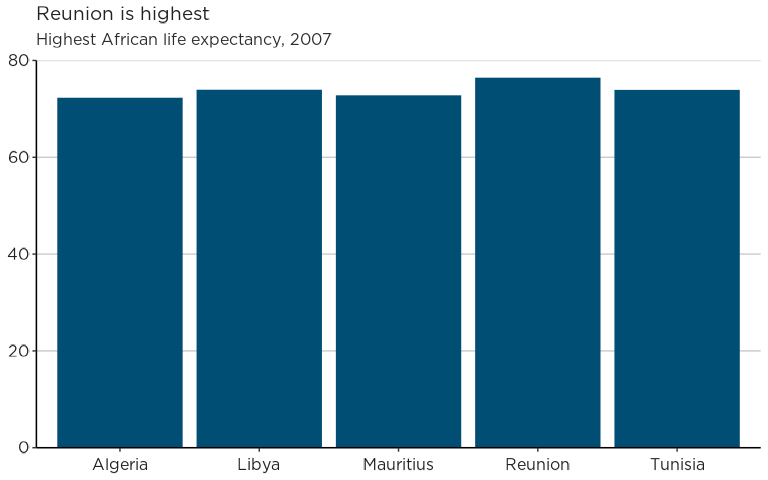

```r
#Prepare data
bar_df <- gapminder |>
  filter(year == 2007 & continent == "Africa") |>
  arrange(desc(lifeExp)) |> # This orders the data - try removing it and running
  head(5) # Selects the top 5

#Make plot
bars <- ggplot(bar_df, aes(x = country, y = lifeExp)) + # NOTE: removed fill from aes
  geom_bar(stat="identity",
           position="identity",
           fill="#004E74" # specified what colour we want
           ) +
  lab_style() +
  theme(legend.position = "none") +
  theme(panel.grid.major.y = element_line(color="#cbcbcb")) +
  scale_y_continuous(limits = c(0,80), expand = c(0, 0)) +
  labs(title="Reunion is highest",
       subtitle = "Highest African life expectancy, 2007",
       x = NULL,
       y = NULL) +
  NULL
```

## Make a stacked bar chart

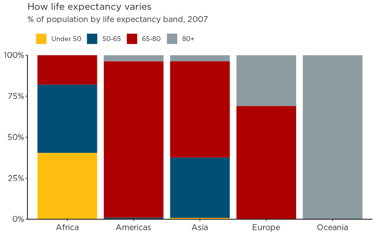

```r
#prepare data
stacked_df <- gapminder |>
  filter(year == 2007) |>
  mutate(lifeExpGrouped = cut(lifeExp,
                    breaks = c(0, 50, 65, 80, 90),
                    labels = c("Under 50", "50-65", "65-80", "80+"))) |>
  group_by(continent, lifeExpGrouped) |>
  summarise(continentPop = sum(as.numeric(pop)))

#set order of stacks by changing factor levels
stacked_df$lifeExpGrouped = factor(stacked_df$lifeExpGrouped, levels = rev(levels(stacked_df$lifeExpGrouped)))

#create plot
stacked_bars <- ggplot(data = stacked_df,
                       aes(x = continent,
                           y = continentPop,
                           fill = lifeExpGrouped)) +
  geom_bar(stat = "identity",
           position = "fill") +
  lab_style() +
  scale_y_continuous(labels = scales::percent, expand = c(0, 0)) +
  labs(title = "How life expectancy varies",
       subtitle = "% of population by life expectancy band, 2007",
       x = NULL,
       y = NULL) +
  theme(legend.position = "top",
        legend.justification = "left",
        legend.title=element_blank()) +
  guides(fill = guide_legend(reverse = TRUE))
```

## Make a grouped bar chart

Making a grouped bar chart is very similar to making a bar chart.

You just need to change `position = "identity"` to `position = "dodge"`, and set the fill aesthetically instead:

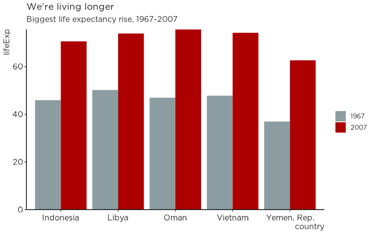

```r
#Prepare data
grouped_bar_df <- gapminder |>
  filter(year == 1967 | year == 2007) |>
  select(country, year, lifeExp) |>
  spread(year, lifeExp) |>
  mutate(gap = `2007` - `1967`) |>
  arrange(desc(gap)) |>
  head(5) |>
  gather(key = year,
         value = lifeExp,
         -country,
         -gap)

#Make plot
grouped_bars <- ggplot(grouped_bar_df,
                       aes(x = country,
                           y = lifeExp,
                           fill = as.factor(year))) +
  geom_bar(stat="identity", position="dodge") +
  scale_y_continuous(expand = c(0, 0)) +
  lab_style() +
  theme(legend.title=element_blank()) + # remove the legend title
  labs(title="We're living longer",
       subtitle = "Biggest life expectancy rise, 1967-2007")
```

Maybe we don’t want to use a dark red in this instance. The UofL colour pallet is:

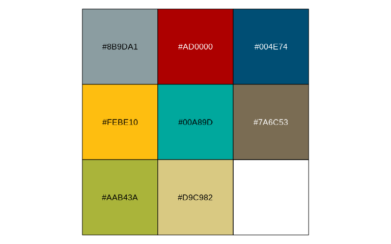

```r
scales::show_col(c("#8B9DA1", "#AD0000", "#004E74", "#FEBE10" ,"#00A89D","#7A6C53",  "#AAB43A", "#D9C982"))
```

We can easily change the colors to say the yellow and green/blue (or any other colour we want - doesn’t have to be one listed). Perhaps we’ll add some horizontal lines and drop the axis titles too. Note how the main plot has already been saved as `grouped_bars` and we are making changes to that.

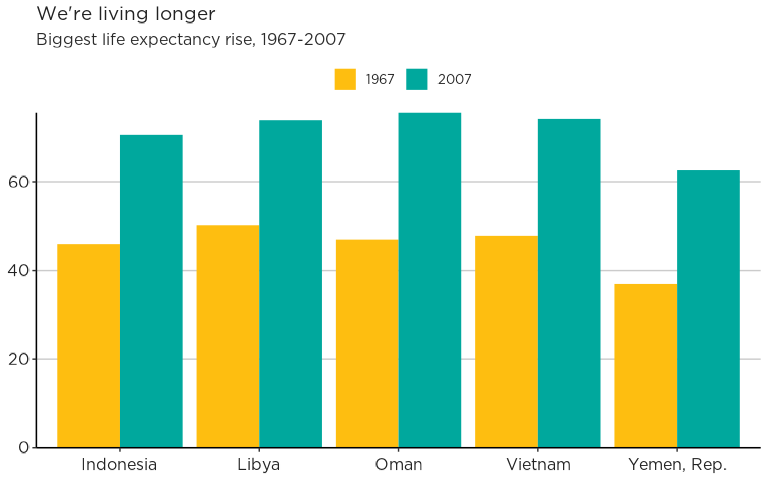

```r
grouped_bars +
  scale_fill_manual(values = c("#FEBE10" ,"#00A89D")) +
  labs(title ="We're living longer",
       subtitle = "Biggest life expectancy rise, 1967-2007",
       x = NULL,
       y = NULL) +
   theme(legend.position = "top",
        legend.title=element_blank(),
        panel.grid.major.y = element_line(color="#cbcbcb"))
```

## Make a dumbbell chart

Another way of showing difference is a dumbbell chart:

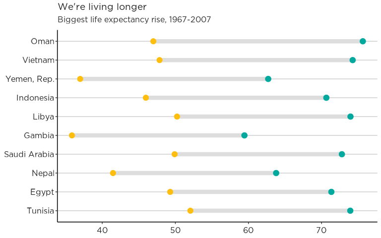

```r
library("ggalt")
library("tidyr")

#Prepare data
dumbbell_df <- gapminder |>
  filter(year == 1967 | year == 2007) |>
  select(country, year, lifeExp) |>
  spread(year, lifeExp) |>
  mutate(gap = `2007` - `1967`) |>
  arrange(desc(gap)) |>
  head(10)

#Make plot
ggplot(dumbbell_df, aes(x = `1967`, xend = `2007`, y = reorder(country, gap), group = country)) +
  geom_dumbbell(colour = "#dddddd",
                size = 3,
                colour_x = "#FEBE10",
                colour_xend = "#00A89D") +
  lab_style() +
  theme(panel.grid.major.y = element_line(color="#cbcbcb")) +
  labs(title="We're living longer",
       subtitle="Biggest life expectancy rise, 1967-2007",
       x = NULL,
       y = NULL)
```

In this case we may decide to also get rid of the axis and axis ticks!

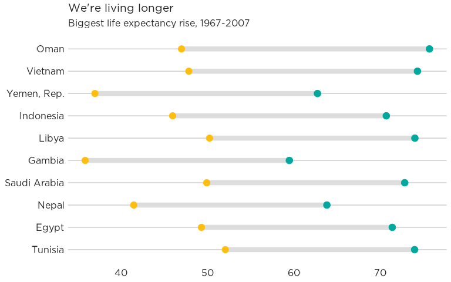

```r
#Make plot
ggplot(dumbbell_df, aes(x = `1967`, xend = `2007`, y = reorder(country, gap), group = country)) +
  geom_dumbbell(colour = "#dddddd",
                size = 3,
                colour_x = "#FEBE10",
                colour_xend = "#00A89D") +
  lab_style() +
  theme(panel.grid.major.y = element_line(color="#cbcbcb"),
        axis.ticks = element_blank(), # Removes ticks
        axis.line = element_blank()) + # Removes axis lines
  labs(title="We're living longer",
       subtitle="Biggest life expectancy rise, 1967-2007",
       x = NULL,
       y = NULL)
```

## Make a histogram

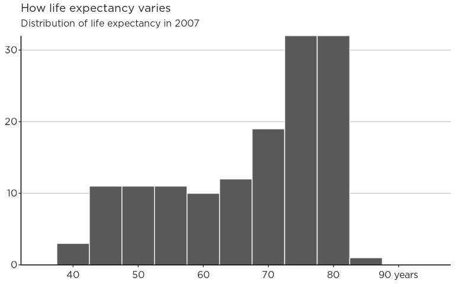

```r
hist_df <- gapminder |>
  filter(year == 2007)

ggplot(hist_df, aes(lifeExp)) +
  geom_histogram(binwidth = 5, colour = "white") +
  lab_style() +
  scale_y_continuous(expand = c(0, 0)) +
  scale_x_continuous(limits = c(35, 95),
                     breaks = seq(40, 90, by = 10),
                     labels = c("40", "50", "60", "70", "80", "90 years")) +
  theme(panel.grid.major.y = element_line(color="#cbcbcb")) +
  labs(title = "How life expectancy varies",
       subtitle = "Distribution of life expectancy in 2007",
       x = NULL,
       y = NULL)
```

## Add labels based on your data

You can add lots of different annotations, lines, arrows, etc., to your figures - though sometimes it’s easier to do this after the fact in another program.

Adding annotations to your chart lets you specify exactly the x and y coordinates. This is very useful if we want to add a text annotation in a specific place, but would be very tedious to repeat.

Fortunately, if you want to add labels to all your data points, you can simply set the position based on your data instead.

Let’s say we want to add data labels to our bar chart (we will also flip it over using `coord_flip` and custom it with some other functions):

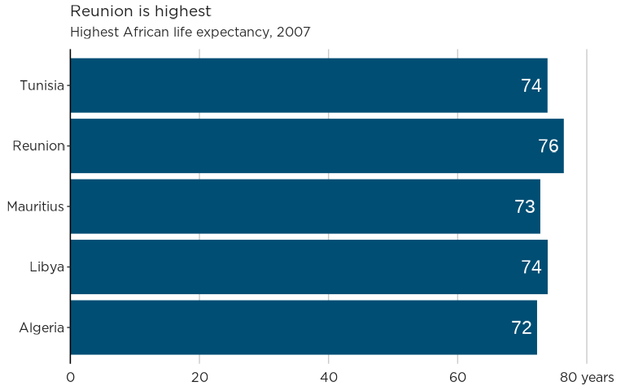

```r
bars +
  coord_flip() + # flips the chart onto its side
  theme(panel.grid.major.x = element_line(color="#cbcbcb"),
        panel.grid.major.y=element_blank(), # changes our gridlines
        axis.line.x = element_blank(),  # remove x axis line
        axis.ticks.x = element_blank()) + # Removes ticks
  scale_y_continuous(limits=c(0,85), # set the linits of the y axis
                     expand = c(0,0), # removes gaps
                   breaks = seq(0, 80, by = 20), # set the breaks 0, 20, 40, 60, 80
                   labels = c("0","20", "40", "60", "80 years")) + # here we specifically change the axis labels
  geom_label(aes(x = country, y = lifeExp, label = round(lifeExp, 0)), # finally we use geom_label to add our text
             hjust = 1,
             vjust = 0.5,
             colour = "white",
             fill = NA,
             label.size = NA,
             size = 6)
```

## Spliting charts into multiples

This is easy in ggplot2 and is called faceting. You will do this a lot.

### Facets

If you have data that you want to visualize split up by some variable, you need to use `facet_wrap` or `facet_grid`.

Add the variable you want to divide by to this line of code: `facet_wrap( ~ variable)`.

An additional argument to facet wrap, `ncol`, allows you to specify the number of columns:

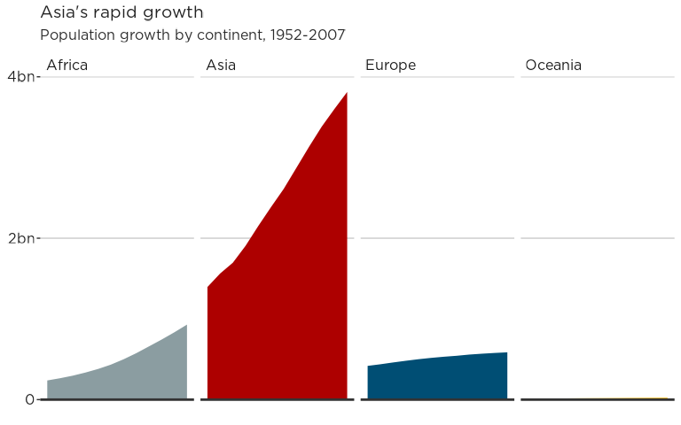

```r
#Prepare data
facet <- gapminder |>
  filter(continent != "Americas") |> # Anything that is NOT the "Americas"
  group_by(continent, year) |>
  summarise(pop = sum(as.numeric(pop)))

#Make plot
facet_plot <- ggplot() +
  geom_area(data = facet, aes(x = year, y = pop, fill = continent)) +
  facet_wrap( ~ continent, ncol = 4) +
  lab_style() +
  scale_y_continuous(breaks = c(0, 2000000000, 4000000000),
                     labels = c(0, "2bn", "4bn")) +
  theme(legend.position = "none",
        axis.text.x = element_blank(),
        panel.grid.major.y = element_line(color="#cbcbcb"),
        axis.ticks.x = element_blank(),
        axis.line = element_blank()) +  # remove x axis line
  geom_hline(yintercept = 0, size = 1, colour = "#333333") + # add our own 0 line back in to remove gap. play around and you'll see why
  labs(title = "Asia's rapid growth",
       subtitle = "Population growth by continent, 1952-2007",
       x = NULL,
       y = NULL)

facet_plot
```

### Free scales

You may have noticed in the chart above that Oceania has disappeared entirely with its relatively small population.

By default, faceting uses fixed axis scales across the small multiples. **It’s always best to use the same y axis scale across small multiples**, to avoid misleading, but sometimes you may need to set these independently for each multiple, which we can do by adding the argument `scales = "free"`.

If you just want to free the scales for one axis, set the argument to `free_x` or `free_y`.

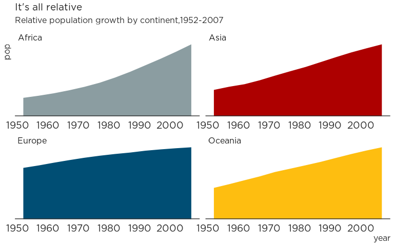

```r
#Make plot
facet_plot_free <- ggplot() +
  geom_area(data = facet, aes(x = year, y = pop, fill = continent)) +
  facet_wrap(~ continent, scales = "free") +
  lab_style() +
  scale_y_continuous(expand = c(0,0)) +
  geom_hline(yintercept = 0, size = 1, colour = "#333333") +
  theme(legend.position = "none",
        axis.text = element_blank(),
        axis.ticks = element_blank(),
        axis.line = element_blank()) +
  labs(title = "It's all relative",
       subtitle = "Relative population growth by continent,1952-2007")

facet_plot_free
```

Anyway, like I say the possibilities are endless.

# Adding P values to your figures

For a more in depth view, I suggest looking at the vignettes for the rstatix and [ggprism](https://csdaw.github.io/ggprism/articles/pvalues.html) packages. As i mentioned the latter will style your plots like GraphPad Prism - I wont judge.

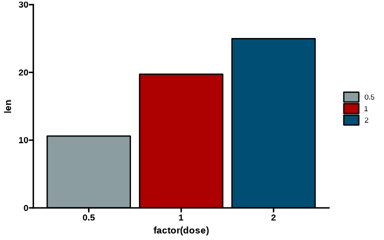

```r
# This is just to show you the theme

library(ggprism) # load the package (you may need to install it first)

ggplot(ToothGrowth, aes(x = factor(dose), y = len)) +
  stat_summary(aes(fill = factor(dose)), na.rm = TRUE,
               geom = "col", fun = mean, colour = "black", size = 0.9) +
  scale_y_continuous(limits = c(0, 30), expand = c(0, 0)) +
  theme_prism()
```

```r
detach("package:ggprism", unload=TRUE) # we'll unload this package as we don't need it any more
```

The data I used above, `ToothGrowth` is available in R. You can view it simply by typing `ToothGrowth`. There are several datasets availiable that you can use to play around with.

```r
create_dt(ToothGrowth)
```

| len | supp | dose |
| --- | --- | --- |
| 4.2 | VC | 0.5 |
| 11.5 | VC | 0.5 |
| 7.3 | VC | 0.5 |
| 5.8 | VC | 0.5 |
| 6.4 | VC | 0.5 |
| 10 | VC | 0.5 |
| 11.2 | VC | 0.5 |
| 11.2 | VC | 0.5 |
| 5.2 | VC | 0.5 |
| 7 | VC | 0.5 |

[output cut: 50 more lines]

## P values

`labPlots` includes the `add_pvalue()` function to easily add p-values from a simple `data.frame` to your plots. This is *borrowed* directly from `ggprism` which is a re-written version of `stat_pvalue_manual()` from the `ggpubr` package, which itself is based on the `geom_signif()` function from the `ggsignif` package… `add_pvalue()` is more flexible to different inputs than `stat_pvalue_manual()` and also allows you to change the look of the brackets and text more easily.

## Basic Use

To add significance brackets to a plot, you need a minimal `data.frame` with 4 columns and several rows corresponding to the number of brackets you want to add. The 4 columns should correspond to these 4 function arguments:

`xmin`, the left-hand position of the bracket (default column name is “group1”) `xmax`, the right-hand position of the bracket (default column name is “group2”) `label`, the text to go on the brackets (default column name is “label”) `y.position`, the vertical position of the bracket (default column name is “y.position”)

For grouped or faceted data, you’ll also need a column which is named according to the grouping variable. See the **many more examples** [here](https://csdaw.github.io/ggprism/articles/pvalues.html).

Let’s see how this works in practice. First we’ll plot the `sleep` data set which is packaged with R.

```r
create_dt(sleep)
```

| extra | group | ID |
| --- | --- | --- |
| 0.7 | 1 | 1 |
| -1.6 | 1 | 2 |
| -0.2 | 1 | 3 |
| -1.2 | 1 | 4 |
| -0.1 | 1 | 5 |
| 3.4 | 1 | 6 |
| 3.7 | 1 | 7 |
| 0.8 | 1 | 8 |
| 0 | 1 | 9 |
| 2 | 1 | 10 |

[output cut: 10 more lines]

```r
# we can also look at the structure of the data str()
str(sleep)
```

```
## 'data.frame':    20 obs. of  3 variables:
##  $ extra: num  0.7 -1.6 -0.2 -1.2 -0.1 3.4 3.7 0.8 0 2 ...
##  $ group: Factor w/ 2 levels "1","2": 1 1 1 1 1 1 1 1 1 1 ...
##  $ ID   : Factor w/ 10 levels "1","2","3","4",..: 1 2 3 4 5 6 7 8 9 10 ...
```

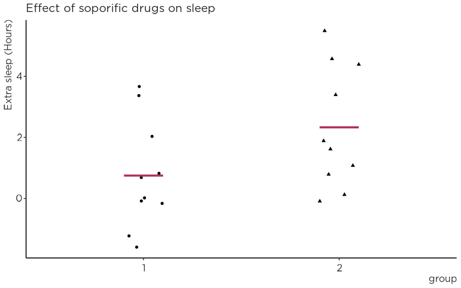

```r
# create a jitter plot of the sleep data set
# and indicate the means
p <- ggplot(sleep, aes(x = group, y = extra)) +
  geom_jitter(aes(shape = group), width = 0.1) +
  stat_summary(geom = "crossbar", fun = mean, colour = "maroon", width = 0.2) +
  lab_style() +
  theme(legend.position = "none") +
  labs(title = "Effect of soporific drugs on sleep",
       y = "Extra sleep (Hours)")
p
```

Next, we’ll perform a t-test using the built in t-test function in R and obtain a p-value for the difference between the two means.

```r
# perform a t-test and obtain the p-value
result <- t.test(extra ~ group, data = sleep)$p.value # run test and extract just the p.value. Run t.test(extra ~ group, data = sleep) to see all the information returned
result <- signif(result, digits = 3) # round result to 3 significant figures
pander(result)
```

*0.0794*

It’s not significant, but we’ll go ahead anyway. Construct a p-value `data.frame` for `add_pvalue()` to use.

```r
df_p_val <- data.frame(
  group1 = "1",
  group2 = "2",
  label = result, # this is our p value
  y.position = 6 # this is where we want to display it on out figure - this can be done automatically
)

pander(df_p_val)
```

| group1 | group2 | label | y.position |
| --- | --- | --- | --- |
| 1 | 2 | 0.0794 | 6 |

Finally, we’ll add this p-value to our plot. Because we have used the default column names (see above) in our p-value table, we don’t necessarily have to specify any `add_pvalue()` arguments. However, here we’ll do it for clarity’s sake. Additionally, if your p-value table has special column names, you will need to specify them in `add_pvalue()`.

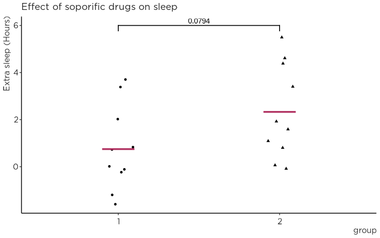

```r
# add p-value brackets
p1 <- p + add_pvalue(df_p_val,
                     xmin = "group1",
                     xmax = "group2",
                     label = "label",
                     y.position = "y.position",
                     label.size = 4)

p1
```

Because our column names are the same we don’t actually need to add them, the following will give us the same result:

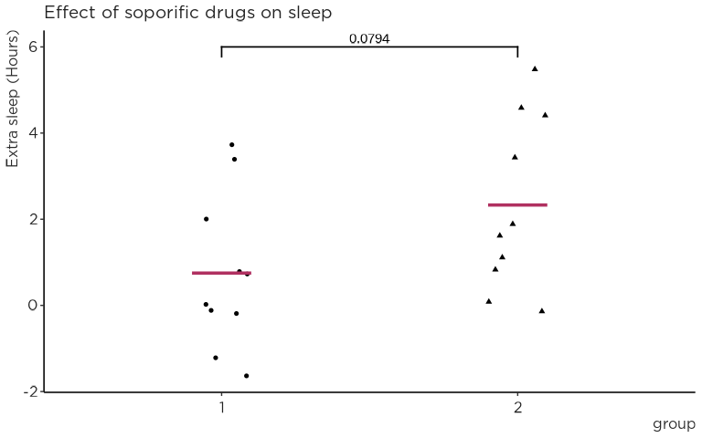

```r
# add p-value brackets
p2 <- p + add_pvalue(df_p_val, label.size = 4)

p2
```

## Using the `rstatix` package

As `add_pvalue()` is ultimately just a rewritten version of `stat_pvalue_manual()`, it works well with the `rstatix` [package](https://github.com/kassambara/rstatix).

With `rstatix`, you can automatically perform the statistical test and create the p-value table with the appropriate x and y position in a single step. There are a lot of other useful things you can also do so check it out.

Below is an example of adding multiple adjusted p values to a faceted plot.

```r
# Data preparation
# here we are generating a dataframe, though often you will import one from Excel or a csv file

df <- tibble::tribble(
  ~sample_type, ~expression, ~cancer_type,   ~gene,
      "cancer",        25.8,       "Lung", "Gene1",
      "cancer",        25.5,      "Liver", "Gene1",
      "cancer",        22.4,      "Liver", "Gene1",
      "cancer",        21.2,       "Lung", "Gene1",
      "cancer",        24.5,      "Liver", "Gene1",
      "cancer",        27.3,      "Liver", "Gene1",
      "cancer",        30.9,      "Liver", "Gene1",
      "cancer",        17.6,     "Breast", "Gene1",
      "cancer",        19.7,       "Lung", "Gene1",
      "cancer",         9.7,     "Breast", "Gene1",
      "cancer",        15.2,     "Breast", "Gene2",
      "cancer",        26.4,      "Liver", "Gene2",
      "cancer",        25.8,       "Lung", "Gene2",
      "cancer",         9.7,     "Breast", "Gene2",
      "cancer",        21.2,       "Lung", "Gene2",
      "cancer",        24.5,      "Liver", "Gene2",
      "cancer",        14.5,     "Breast", "Gene2",
      "cancer",        19.7,       "Lung", "Gene2",
      "cancer",        25.2,       "Lung", "Gene2",
      "normal",        43.5,       "Lung", "Gene1",
      "normal",        76.5,      "Liver", "Gene1",
      "normal",        21.9,     "Breast", "Gene1",
      "normal",        69.9,      "Liver", "Gene1",
      "normal",       101.7,      "Liver", "Gene1",
      "normal",        80.1,      "Liver", "Gene1",
      "normal",        19.2,     "Breast", "Gene1",
      "normal",        49.5,       "Lung", "Gene1",
      "normal",        34.5,     "Breast", "Gene1",
      "normal",        51.9,       "Lung", "Gene1",
      "normal",        67.5,       "Lung", "Gene2",
      "normal",          30,     "Breast", "Gene2",
      "normal",        76.5,      "Liver", "Gene2",
      "normal",        88.5,      "Liver", "Gene2",
      "normal",        69.9,      "Liver", "Gene2",
      "normal",        49.5,       "Lung", "Gene2",
      "normal",        80.1,      "Liver", "Gene2",
      "normal",        79.2,      "Liver", "Gene2",
      "normal",        12.6,     "Breast", "Gene2",
      "normal",        97.5,      "Liver", "Gene2",
      "normal",        64.5,      "Liver", "Gene2"
  )
```

The `rstatix` has a useful function to get summary data called `get_summary_stats()` if you want to get the details of this or any R function you can type `?function()` so in this case it would be `?get_summary_stats()`.

```r
# Summary statistics
df |>
  group_by(gene, cancer_type, sample_type) |>
  get_summary_stats(expression, type = "common") |>
  create_dt()
```

| sample_type | cancer_type | gene | variable | n | min | max | median | iqr | mean | sd | se | ci |
| --- | --- | --- | --- | --- | --- | --- | --- | --- | --- | --- | --- | --- |
| cancer | Breast | Gene1 | expression | 2 | 9.7 | 17.6 | 13.65 | 3.95 | 13.65 | 5.586 | 3.95 | 50.19 |
| normal | Breast | Gene1 | expression | 3 | 19.2 | 34.5 | 21.9 | 7.65 | 25.2 | 8.166 | 4.715 | 20.286 |
| cancer | Liver | Gene1 | expression | 5 | 22.4 | 30.9 | 25.5 | 2.8 | 26.12 | 3.205 | 1.433 | 3.98 |
| normal | Liver | Gene1 | expression | 4 | 69.9 | 101.7 | 78.3 | 10.65 | 82.05 | 13.764 | 6.882 | 21.902 |
| cancer | Lung | Gene1 | expression | 3 | 19.7 | 25.8 | 21.2 | 3.05 | 22.233 | 3.179 | 1.835 | 7.896 |
| normal | Lung | Gene1 | expression | 3 | 43.5 | 51.9 | 49.5 | 4.2 | 48.3 | 4.327 | 2.498 | 10.748 |
| cancer | Breast | Gene2 | expression | 3 | 9.7 | 15.2 | 14.5 | 2.75 | 13.133 | 2.994 | 1.729 | 7.437 |
| normal | Breast | Gene2 | expression | 2 | 12.6 | 30 | 21.3 | 8.7 | 21.3 | 12.304 | 8.7 | 110.544 |
| cancer | Liver | Gene2 | expression | 2 | 24.5 | 26.4 | 25.45 | 0.95 | 25.45 | 1.344 | 0.95 | 12.071 |
| normal | Liver | Gene2 | expression | 7 | 64.5 | 97.5 | 79.2 | 11.1 | 79.457 | 11.042 | 4.174 | 10.212 |

[output cut: 2 more lines]

Run the test and adjust the p values for multiple comparisons. Here we will use `holm` which is similar to the `bonferroni` adjustment (though not as strict). You can find all the available methods by typing `?adjust_pvalue()`

```r
# Statistical test
# group the data by cancer type and gene
# Compare expression values of normal and cancer samples
stat.test <- df |>
  group_by(cancer_type, gene) |>
  t_test(expression ~ sample_type) |> # here we are running t-tests on each of the groups generated above
  adjust_pvalue(method = "holm") |>
  add_significance() # This is the function from rstatix that generates our usable p value table

stat.test |>
  mutate_if(is.numeric,
            round,
            digits = 4) |>
  create_dt()
```

| cancer_type | gene | .y. | group1 | group2 | n1 | n2 | statistic | df | p | p.adj | p.adj.signif |
| --- | --- | --- | --- | --- | --- | --- | --- | --- | --- | --- | --- |
| Breast | Gene1 | expression | cancer | normal | 2 | 3 | -1.8778 | 2.9179 | 0.16 | 0.45 | ns |
| Breast | Gene2 | expression | cancer | normal | 3 | 2 | -0.9207 | 1.0797 | 0.517 | 0.517 | ns |
| Liver | Gene1 | expression | cancer | normal | 5 | 4 | -7.9562 | 3.2613 | 0.003 | 0.0122 | * |
| Liver | Gene2 | expression | cancer | normal | 2 | 7 | -12.6174 | 6.5326 | 0 | 0 | **** |
| Lung | Gene1 | expression | cancer | normal | 3 | 3 | -8.4096 | 3.6718 | 0.0016 | 0.0079 | ** |
| Lung | Gene2 | expression | cancer | normal | 4 | 2 | -3.8939 | 1.0557 | 0.15 | 0.45 | ns |

Plot our data and add the p values

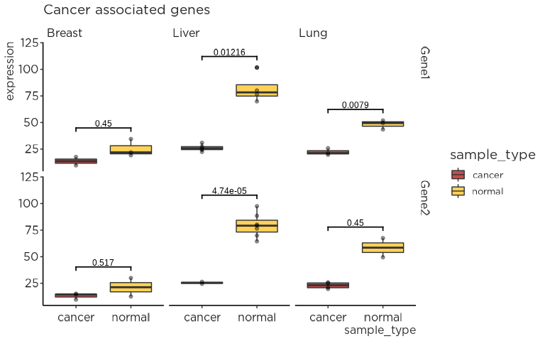

```r
# Create boxplot

bxp <-
  df |>
  ggplot() +
  geom_boxplot(aes(x = sample_type, y = expression, fill = sample_type),alpha = 0.7) +
  geom_point(aes(x = sample_type, y = expression),alpha = 0.4) +
  scale_fill_manual(values = c("#AD0000", "#FEBE10")) + # change colours manualy - we could also omit any colour
  facet_grid(gene~cancer_type) +
  ylim(NA,120) + # Adjust the limits to male room for p values (not always needed)
  lab_style() +
  labs(title = "Cancer associated genes")

# Add adjusted p-values
stat.test <-
  stat.test |>
  add_xy_position(x = "sample_type")

bxp + add_pvalue(stat.test, label = "p.adj")
```

Of course, we may not care about non-significant findings, in which case we can simply drop them.

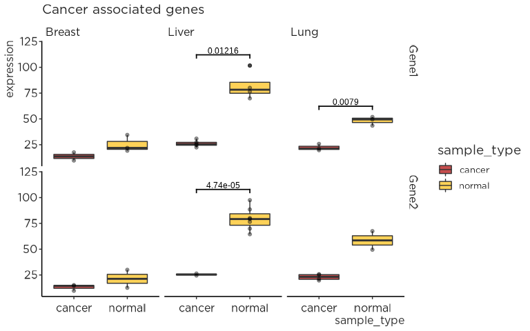

```r
# Hide ns
bxp + add_pvalue(
  filter(stat.test, p.adj < 0.05), label = "p.adj", #filter out any value less than 0.05

  )
```

Or just go for the good ole * system

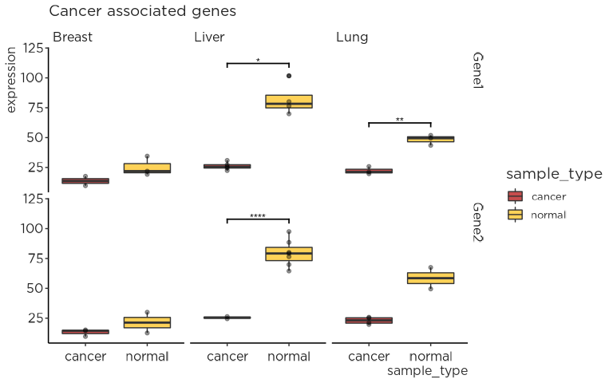

```r
# Hide ns
bxp + add_pvalue(
  filter(stat.test, p.adj < 0.05), label = "p.adj.signif",

  )
```